# Working with Spatial Data

Theodore Wang

8/1/2020

# 1 Background

How do CAFOs affect local community mental health? Air quality? Food quality?

Can we use previous recorded data on environmental quality (air, water) surrounding CAFOs in order to determine the overall general health of nearby communities in the future?

What steps can we take to address the health issues regarding CAFOs after identifying areas with the highest concentration of hogs?

# 2 Preparation

```r
library(tidyverse)
library(tidycensus)
library(readxl)
library(janitor)
library(sf)
```

# 3 Analysis

## 3.1 Data

We can load in the data sets on CAFOs and County Health; we use a specific code to download the files from an online source before reading them into R. R will check if the appropriate file exists and appropriately determine the following course of action. If the file does not exist or is not found in the right directory, R will download the file from the given source and place it into the working directory; if the file does exist and is found, R will not download any files.

```r
# Download CAFO data
if(!file.exists("./List_Of_Permitted_Animal_Facilities2019-11-06.xls")){
  print("CAFO data file does not exist, fetching .xls file from the source")
download.file(url = "https://files.nc.gov/ncdeq/List_Of%20Permitted_Animal_Facilities2019-11-06.xls", destfile = "./List_Of_Permitted_Animal_Facilities2019-11-06.xls")}

# Download county health data
if(!file.exists("./2018_County_Health_Rankings_North_Carolina_Data.xls")){
  print("2018 County Health Rankings North Carolina Data file does not exist, fetching .xls file from the source")
download.file(url = "https://www.countyhealthrankings.org/sites/default/files/media/document/state/downloads/2018%20County%20Health%20Rankings%20North%20Carolina%20Data%20-%20v3.xls", destfile = "./2018_County_Health_Rankings_North_Carolina_Data.xls")}
```

Now that we have finished downloading the files from their sources, we can read the data files and assign them to variable names to work with in R. Both of these files on CAFO data and County Health data have other Excel sheets beyond the data we want, so we specify which sheets we want and which ones we wish to skip.

```r
# Load in CAFO data
cafoData <- read_excel("./List_Of_Permitted_Animal_Facilities2019-11-06.xls", sheet = 1, skip = 2)

# Load in county health data
countyHealth <- read_excel("./2018_County_Health_Rankings_North_Carolina_Data.xls", sheet = 4, skip = 1)
```

[output not shown]

One more data file to download, this time regarding North Carolina Counties.

```r
# Loading and cleaning county map data
if(!file.exists("./NC_Counties.zip")){
  print("NC_Counties.zip does not exist, fetching zip file from the source")
download.file(url = "https://opendata.arcgis.com/datasets/34acbf4a26784f189c9528c1cf317193_0.zip?outSR=%7B%22latestWkid%22%3A3857%2C%22wkid%22%3A102100%7D", destfile = "./NC_Counties.zip")
}

print("NC_counties.zip exists at './NC_Counties.zip'")
```

```
## [1] "NC_counties.zip exists at './NC_Counties.zip'"
```

```r
if(!file.exists("./NC_Counties/counties.shp")){
  print("unzipped folder and shp not detected, unzipping 'NC_Counties.zip' to './NC_counties'")
unzip("./NC_Counties.zip",exdir = "./NC_Counties",overwrite = T)
}

ncShp <- st_read("./NC_Counties/counties.shp",stringsAsFactors =F)
ncShp <- ncShp %>% clean_names(case = "snake")
head(ncShp)
```

```
## Simple feature collection with 6 features and 10 fields
## geometry type:  POLYGON
## dimension:      XY
## bbox:           xmin: -9055175 ymin: 4183784 xmax: -8660677 ymax: 4375561
## epsg (SRID):    3857
## proj4string:    +proj=merc +a=6378137 +b=6378137 +lat_ts=0.0 +lon_0=0.0 +x_0=0.0 +y_0=0 +k=1.0 +units=m +nadgrids=@null +wktext +no_defs
##   fid objectid perimeter    co_name co_abbr    acres shape_leng   ro shape_le_1
## 1   1        1  156473.0 ROCKINGHAM    ROCK 366053.1   513361.8 WSRO   194502.4
## 2   2        2  166183.5   GUILFORD    GUIL 420968.9   545220.4 WSRO   205797.6
## 3   3        3  143114.5   ALAMANCE    ALAM 278127.0   469535.0 WSRO   177273.0
## 4   4        4  116938.2  ALEXANDER    ALEX 168641.0   383654.7  MRO   144599.5
## 5   5        5  180894.2   RANDOLPH    RAND 505668.0   593483.6 WSRO   223033.8
## 6   6        6  174751.8      WAYNE    WAYN 356469.2   573331.4 WARO   214578.9
##    shape_area                       geometry
## 1 15945261643 POLYGON ((-8853514 4333890,...
## 2 18337394619 POLYGON ((-8909473 4336065,...
## 3 12115206198 POLYGON ((-8853514 4333890,...
## 4  7345996919 POLYGON ((-9020123 4306916,...
## 5 22026881771 POLYGON ((-8910805 4289745,...
## 6 15527790010 POLYGON ((-8690116 4243719,...
```

## 3.2 Data Cleaning/Wrangling

We can now begin to clean the data.

Here we clean the CAFO data, first removing rows with missing “NA” values and then selecting two data columns, “County Name” and “Allowable Count”, to a variable to work with. The aggregate command subsets the data into more organized groups.

```r
# Dropping rows with missing data using "drop_na()" in CAFO data
cafoNoNA <- drop_na(cafoData)
cafoVariables <- cafoNoNA %>% select(c("County Name", "Allowable Count")) %>% clean_names(case = "snake")
cafoVariables <- aggregate(allowable_count~county_name, data = cafoVariables, FUN = sum)
head(cafoVariables)
```

```
##   county_name allowable_count
## 1       Anson            8336
## 2    Beaufort            2245
## 3      Bertie            6544
## 4      Bladen           63180
## 5    Columbus           12408
## 6      Craven            4900
```

We do the same thing here with the County Health data. With this data set, we only want to work with the “County” column, mentally unhealthy days column, air quality index column, and food environment index column. We also renamed one column to cause less confusion.

Mentally unhealthy days are measured in days. Food environment index is measured on a scale from 0 to 10, with 0 being the worst and 10 being the best. The air quality score is measured in PM2.5, a standard measurement of particles in the air; the higher the measure, the more hazy and thick the air will appear to be, and the poorer the quality of air.

```r
# Selecting columns from County Health data
countyVariables <- countyHealth %>% select(c("County", "Mentally Unhealthy Days", "Average Daily PM2.5", "Food Environment Index")) %>% rename("Air Quality Score Rating" = "Average Daily PM2.5") %>% rename("County Name" = "County") %>% clean_names(case = "snake")
head(countyVariables)
```

```
## # A tibble: 6 x 4
##   county_name mentally_unhealthy_da… air_quality_score_rat… food_environment_in…
##   <chr>                        <dbl>                  <dbl>                <dbl>
## 1 <NA>                          3.92                   9.05                  6.4
## 2 Alamance                      4.28                   9.3                   7.1
## 3 Alexander                     4.20                   9.6                   8
## 4 Alleghany                     4.26                   8.3                   8.2
## 5 Anson                         4.31                   9.5                   6.3
## 6 Ashe                          4.12                   8.2                   8
```

Now that we have cleaned up our separate data sets, we can combine them into one large data set to work from. We do a little more tidying along the way, just to remove unwanted missing values present as a result of joining data frames and to reorder certain data columns.

```r
# This code combines the data frames we cleaned up earlier into one large dataframe
finalData <- countyVariables %>% left_join(cafoVariables, by = "county_name")
finalData
```

```
## # A tibble: 101 x 5
##    county_name mentally_unheal… air_quality_sco… food_environmen…
##    <chr>                  <dbl>            <dbl>            <dbl>
##  1 <NA>                    3.92             9.05              6.4
##  2 Alamance                4.28             9.3               7.1
##  3 Alexander               4.20             9.6               8
##  4 Alleghany               4.26             8.3               8.2
##  5 Anson                   4.31             9.5               6.3
##  6 Ashe                    4.12             8.2               8
##  7 Avery                   4.15             8.3               8.3
##  8 Beaufort                4.13             8.6               7.3
##  9 Bertie                  4.23             8.4               6.3
## 10 Bladen                  4.59             9.1               6.6
## # … with 91 more rows, and 1 more variable: allowable_count <dbl>
```

```r
# Reordering columns in final data frame and removing any rows with NA county names
finalData <- finalData %>% select("county_name", "allowable_count", everything()) %>% replace_na(list("allowable_count" = 0)) %>% drop_na("county_name")
head(finalData)
```

```
## # A tibble: 6 x 5
##   county_name allowable_count mentally_unheal… air_quality_sco… food_environmen…
##   <chr>                 <dbl>            <dbl>            <dbl>            <dbl>
## 1 Alamance                  0             4.28              9.3              7.1
## 2 Alexander                 0             4.20              9.6              8
## 3 Alleghany                 0             4.26              8.3              8.2
## 4 Anson                  8336             4.31              9.5              6.3
## 5 Ashe                      0             4.12              8.2              8
## 6 Avery                     0             4.15              8.3              8.3
```

We can also join the spacial data from the NC_Counties data, too.

```r
# Joins the spatial data frames together
ncShpUpdate <- ncShp %>% select(name = co_name, geometry) %>%
  mutate(name = name %>% str_to_title())

# join to finalData
finalDataGeo <- finalData %>% rename(name = county_name) %>% left_join(ncShpUpdate, by = "name") %>% st_sf()
finalDataGeo
```

```
## Simple feature collection with 100 features and 5 fields (with 1 geometry empty)
## geometry type:  POLYGON
## dimension:      XY
## bbox:           xmin: -9386640 ymin: 4006583 xmax: -8400167 ymax: 4381891
## epsg (SRID):    3857
## proj4string:    +proj=merc +a=6378137 +b=6378137 +lat_ts=0.0 +lon_0=0.0 +x_0=0.0 +y_0=0 +k=1.0 +units=m +nadgrids=@null +wktext +no_defs
## # A tibble: 100 x 6
##    name  allowable_count mentally_unheal… air_quality_sco… food_environmen…
##    <chr>           <dbl>            <dbl>            <dbl>            <dbl>
##  1 Alam…               0             4.28              9.3              7.1
##  2 Alex…               0             4.20              9.6              8
##  3 Alle…               0             4.26              8.3              8.2
##  4 Anson            8336             4.31              9.5              6.3
##  5 Ashe                0             4.12              8.2              8
##  6 Avery               0             4.15              8.3              8.3
##  7 Beau…            2245             4.13              8.6              7.3
##  8 Bert…            6544             4.23              8.4              6.3
##  9 Blad…           63180             4.59              9.1              6.6
## 10 Brun…               0             3.93              8.7              7.6
## # … with 90 more rows, and 1 more variable: geometry <POLYGON [m]>
```

## 3.3 Results

We can finally begin analyzing and visualizing the data!

### 3.3.1 Histogram

Most counties don’t have any allowed CAFO counts, meaning they don’t have any CAFOs at all. In the histogram distribution, this is evident from the large count at the “0” mark.

Of the counties that do have a non-zero number of allowed CAFO counts, most remain under 25,000, and the majority of those under 25,000 measure under 12,500. There are a few counties with 25,000 plus CAFO counts. Most notably, there are 3 counties measuring above 50,000 counts, with one of them representing the maximum number of CAFOs at just under 100,000.

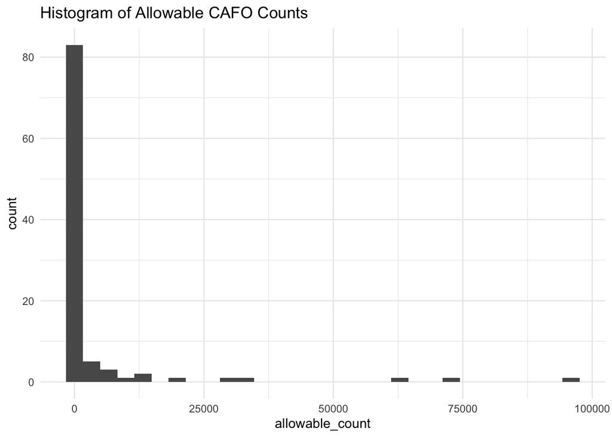

```r
finalData %>% ggplot(aes(x = allowable_count)) + geom_histogram() + labs(title = "Histogram of Allowable CAFO Counts") + theme_minimal()
```

My apologies for the following histograms being sized so small; I could not figure out the scaling and formatting to present the following data in a comprehensible manner.

These histograms measuring the distribution of allowable CAFO counts in each county in North Carolina show that most counties have no CAFOs; you can see this in Alamance, Cabarrus, Hyde, Pitt, and Wake County, just to name a few.

There are histograms showing an abundance of CAFOs, however, most notably Bladen and Duplin County. Other counties with CAFOs include Sampson, Columbus, Edgcombe, Greene, Hertford, Jones, Northhampton, Robeson, and Scotland County.

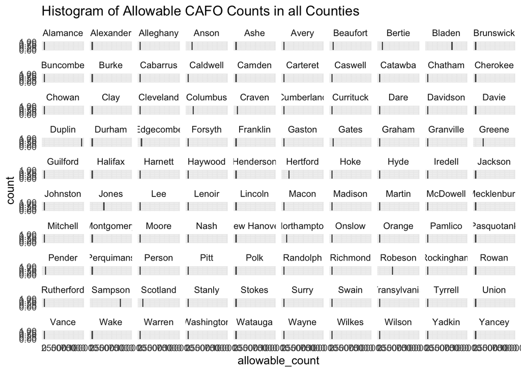

```r
finalData %>% ggplot(aes(x = allowable_count)) + geom_histogram() + labs(title = "Histogram of Allowable CAFO Counts in all Counties") + theme_minimal() + facet_wrap(~county_name)
```

### 3.3.2 Scatter Plots

In order to determine whether there is any relationship between allowable CAFO count and mental health, I constructed a scatter plot of allowable CAFO counts and measured mentally unhealthy days. The following plot shows that most high CAFO count counties have higher than average mentally unhealthy days; however, we cannot immediately attribute this to the presence of CAFOs.

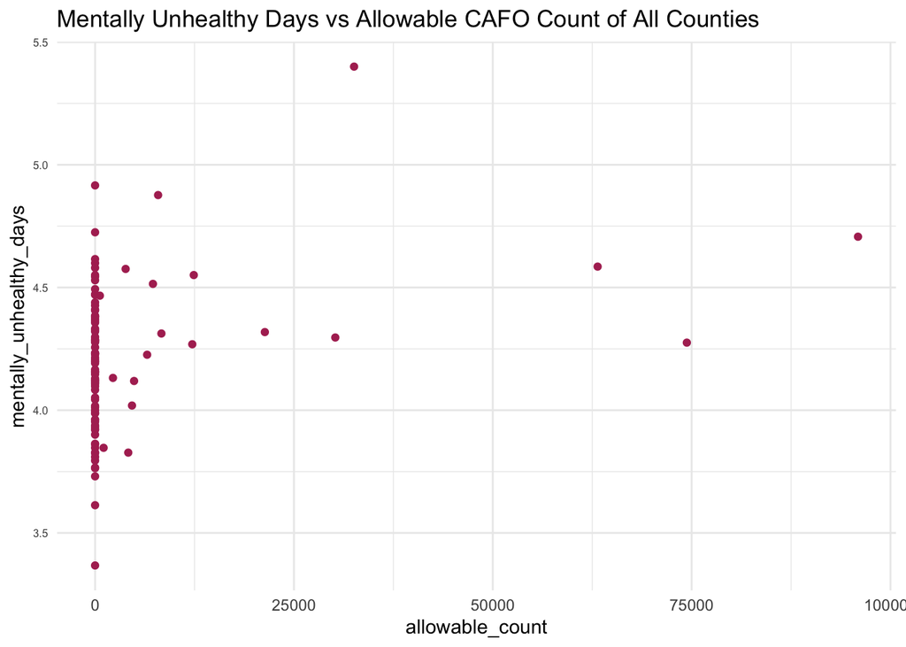

```r
finalData %>% ggplot(aes(x = allowable_count, y = mentally_unhealthy_days)) + geom_point(color = "maroon") + geom_smooth() + labs(title = "Mentally Unhealthy Days vs Allowable CAFO Count of All Counties") + theme_minimal() + theme(axis.text.y = element_text(size = 6))
```

I constructed a similar plot for air quality and whether the presence of CAFOs increases the density of particles in the air. While CAFO counties rank average in air quality score index compared to other non-CAFO counties, there are many non-CAFO counties that score higher PM2.5 levels than CAFO counties. Again, this plot is inconclusive regarding any relationship between the two variables.

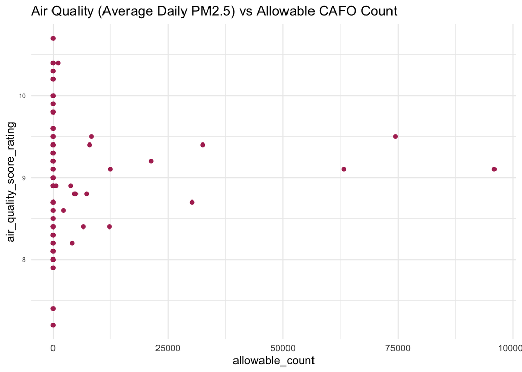

```r
finalData %>% ggplot(aes(x = allowable_count, y = air_quality_score_rating)) + geom_point(color = "maroon") + geom_smooth() + labs(title = "Air Quality (Average Daily PM2.5) vs Allowable CAFO Count") + theme_minimal() + theme(axis.text.y = element_text(size = 6))
```

How about food environment index? This index measures access to healthy foods and is measured on a scale of 0 to 10, with 0 being the worst and 10 being the best. Unfortunately, this scatter plot shows no obvious relationship between poor food environment index and high CAFO counts; in fact, CAFO counties score higher food environment indexes than some non-CAFO counties!

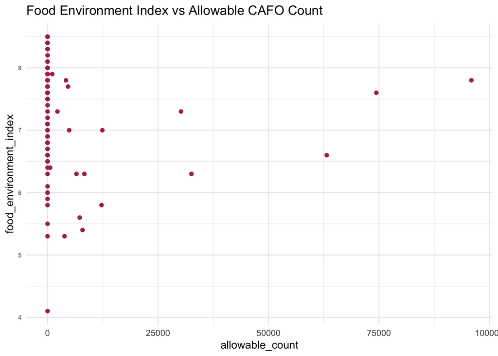

```r
finalData %>% ggplot(aes(x = allowable_count, y = food_environment_index)) + geom_point(color = "maroon") + geom_smooth() + labs(title = "Food Environment Index vs Allowable CAFO Count") + theme_minimal() + theme(axis.text.y = element_text(size = 6))
```

### 3.3.3 Map Plots

Using map plots enables us to identify, on a geo-spatial level, the locations and measurable counts of each county in North Carolina.

The first map plot shows the distribution of CAFO counts in North Carolina. Most of NC is covered in dark purple, signifying that most counties have no CAFOs at all. However, there are some counties that do have CAFOs, shown in colors according to the scale.

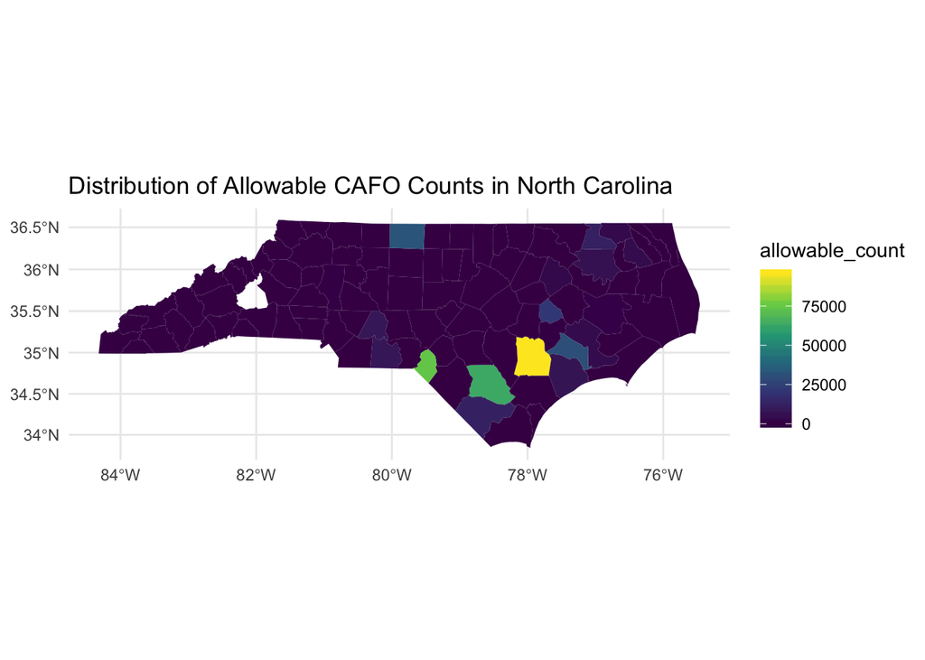

```r
finalDataGeo %>% ggplot(aes(fill = allowable_count)) + geom_sf(color=NA) + scale_fill_viridis_c() + theme_minimal() + labs(title = "Distribution of Allowable CAFO Counts in North Carolina")
```

We can plot other map plots measuring the other variables to see if there are any shared distributions between them. This map plot measures the distribution of mentally unhealthy days throughout North Carolina.

We can see that Duplin County does not average the highest number of mentally unhealthy days, even though it is the county with the highest allowable CAFO count. Instead, that achievement goes to Rockingham County, the lone county up north from the previous map plot. However, that is not to say that CAFO counties rank lowest in the number mentally unhealthy days; Duplin, Scotland, and Bladen County still measure above average in number of mentally unhealthy days.

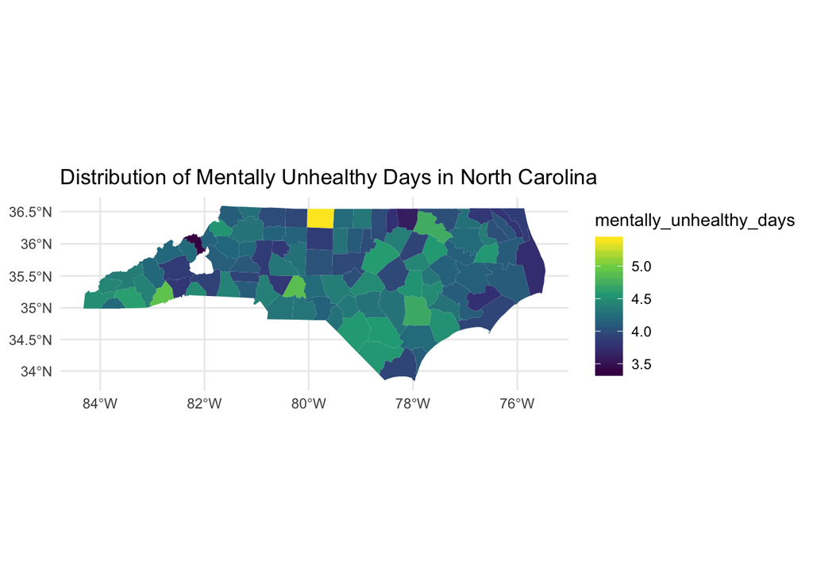

```r
finalDataGeo %>% ggplot(aes(fill = mentally_unhealthy_days)) + geom_sf(color=NA) + scale_fill_viridis_c() + theme_minimal() + labs(title = "Distribution of Mentally Unhealthy Days in North Carolina")
```

Keep in mind that these measurements are scaled; on this particular plot, a high PM2.5 score above 10 doesn’t necessarily mean the air is extremely toxic. On a broader scale, a PM2.5 score of 10 still measures well. Anything above a 12 or 13 represents the threshold where air quality should be questioned.

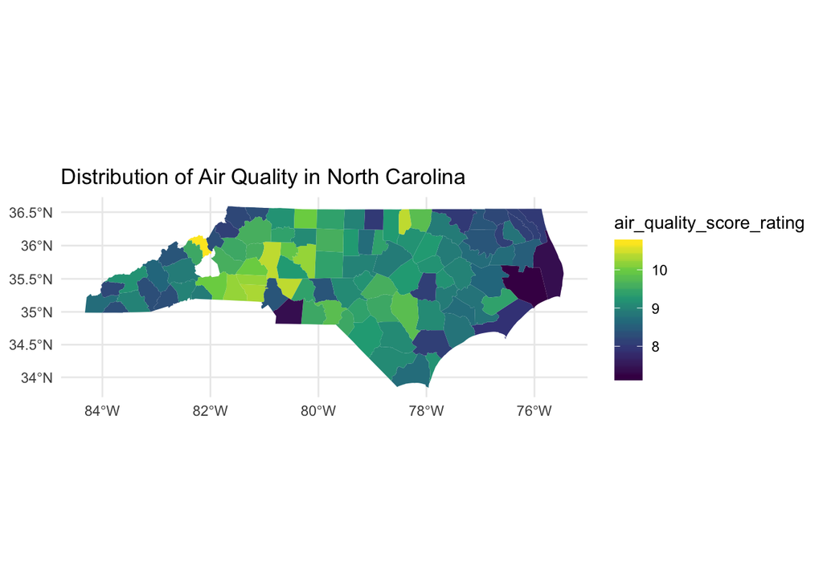

```r
finalDataGeo %>% ggplot(aes(fill = air_quality_score_rating)) + geom_sf(color=NA) + scale_fill_viridis_c() + theme_minimal() + labs(title = "Distribution of Air Quality in North Carolina")
```

Finally, we come to food environment index. Remember that the food environment index measures accessibility to healthy food on a scale of 0 to 10, 0 being the worst and 10 being the best. Once again, the plot shows that CAFO counties don’t necessarily score the poorest, nor do they score the best. Most CAFO counties score average or slightly above average. The onyl noticible counties that score relatively poorly are a cluster of two counties, Halifax County and Edgecombe County, and one poor county that must be starved of healthy foods: Hyde County.

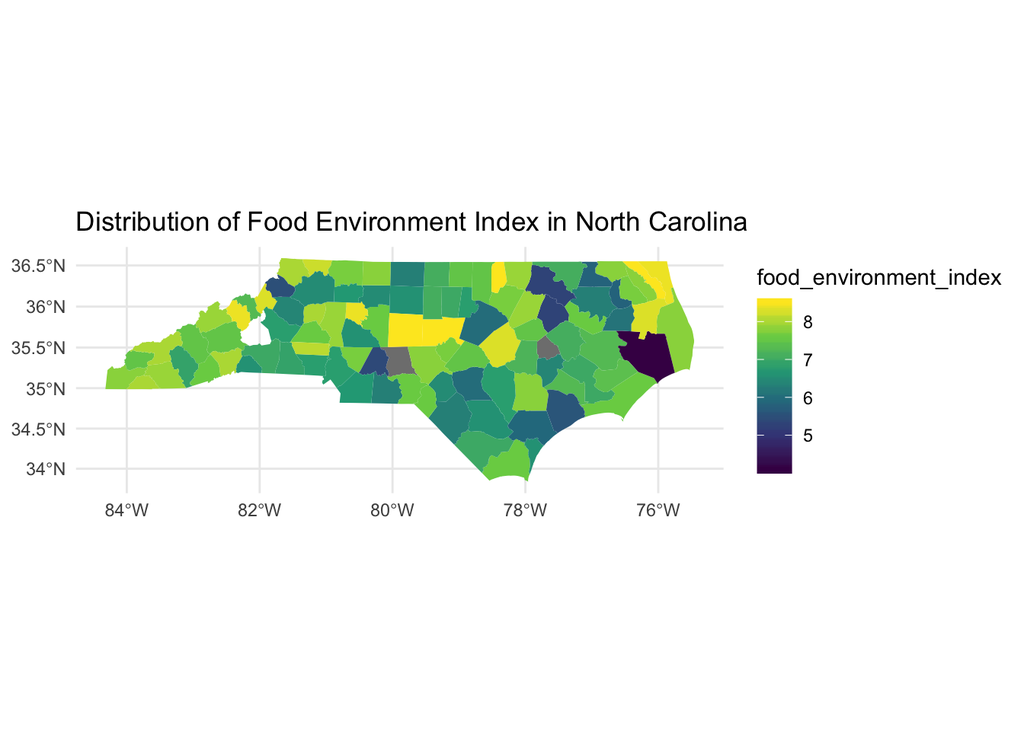

```r
finalDataGeo %>% ggplot(aes(fill = food_environment_index)) + geom_sf(color=NA) + scale_fill_viridis_c() + theme_minimal() + labs(title = "Distribution of Food Environment Index in North Carolina")
```

## 3.4 Discussion

When beginning this study, I imagined that there would be a much greater and obvious relationship beween the presence of CAFOs and impacts it had on mental health and the environmental quality surrounding them, represented by food environment index and air quality. However, from analyzing the data, I can see that there is no such clear relationship.

I had hoped that the scatter plots would show a much clearer trend, but I believe there are too many confounding variables disrupting the nature of the measurements for each county.

CAFO counties scored higher than average number of mentally unhealthy days; this might be a sign fo a potential relationship between CAFOs and mental healthy, but the number of non-CAFO counties with similar numbers doesn’t support this.

CAFO counties scored average in both air quality scorings and food environment indexes.

The map plots only supported this fact; while CAFO counties didn’t necessarily score the best in each variable category, they didn’t score the worst in each variable category either. As I mentioned before, I believe too many confounding variables affected this study, especially on from the data set containing the general health of each county; other variables that could contribute to poor air quality or poor food environment indexes could be a lack of infrastructure and roads leading to healthy food sources or large numbers of industrial zones.

# 4 Feedback

The parts of the homework that I struggled the most with was tidying the data and joining it together so that the column labels and measures would all work properly in one R function. I was most relieved when I managed to get most of the data into one usable data frame.

I spent around 6 to 8 hours on this assignment.

I liked the open-ended nature of this assignment, both in research and in coding. I don’t have to guess and fill in empty parts of the code to fit one exact function; instead, I can use any function I wish and structure the analysis from there.